# examples_0427

Let function $f$ be defined with the algebraic expression below:
$$f(x)~=~6x-3$$

Describe the operation sequence that function $f$ applies to the input.

An inverse function would need to undo those operations in reverse order. What is the operation sequence of the inverse function?

The original $f$ function multiplies by 6 and then subtracts 3. This is based on [PEMDAS](https://en.wikipedia.org/wiki/Order_of_operations).

So, the inverse function adds 3 and then divides by 6.

$$f^{-1}(x)~=~\frac{x+3}{6}$$

Let function $f$ be defined with the algebraic expression below:
$$f(x)~=~5x+9$$

Describe the operation sequence that function $f$ applies to the input.

An inverse function would need to undo those operations in reverse order. What is the operation sequence of the inverse function?

The original $f$ function multiplies by 5 and then adds 9. This is based on [PEMDAS](https://en.wikipedia.org/wiki/Order_of_operations).

So, the inverse function subtracts 9 and then divides by 5.

$$f^{-1}(x)~=~\frac{x-9}{5}$$

Let function $f$ be defined with the algebraic expression below:
$$f(x)~=~\frac{x+7}{4}$$

Describe the operation sequence that function $f$ applies to the input.

An inverse function would need to undo those operations in reverse order. What is the operation sequence of the inverse function?

The original $f$ function adds 7 and then divides by 4. This is based on [PEMDAS](https://en.wikipedia.org/wiki/Order_of_operations).

So, the inverse function multiplies by 4 and then subtracts 7.

$$f^{-1}(x)~=~4x-7$$

Let function $f$ be defined with the algebraic expression below:
$$f(x)~=~\frac{x+7}{8}$$

Describe the operation sequence that function $f$ applies to the input.

An inverse function would need to undo those operations in reverse order. What is the operation sequence of the inverse function?

The original $f$ function adds 7 and then divides by 8. This is based on [PEMDAS](https://en.wikipedia.org/wiki/Order_of_operations).

So, the inverse function multiplies by 8 and then subtracts 7.

$$f^{-1}(x)~=~8x-7$$

Let function $f$ be defined with the algebraic expression below:
$$f(x)~=~\frac{x}{6}-9$$

Describe the operation sequence that function $f$ applies to the input.

An inverse function would need to undo those operations in reverse order. What is the operation sequence of the inverse function?

The original $f$ function divides by 6 and then subtracts 9. This is based on [PEMDAS](https://en.wikipedia.org/wiki/Order_of_operations).

So, the inverse function adds 9 and then multiplies by 6.

$$f^{-1}(x)~=~6(x+9)$$

Let function $f$ be defined with the algebraic expression below:
$$f(x)~=~6x+7$$

Describe the operation sequence that function $f$ applies to the input.

An inverse function would need to undo those operations in reverse order. What is the operation sequence of the inverse function?

The original $f$ function multiplies by 6 and then adds 7. This is based on [PEMDAS](https://en.wikipedia.org/wiki/Order_of_operations).

So, the inverse function subtracts 7 and then divides by 6.

$$f^{-1}(x)~=~\frac{x-7}{6}$$

Let function $f$ be defined with the algebraic expression below:
$$f(x)~=~\frac{x-7}{3}$$

Describe the operation sequence that function $f$ applies to the input.

An inverse function would need to undo those operations in reverse order. What is the operation sequence of the inverse function?

The original $f$ function subtracts 7 and then divides by 3. This is based on [PEMDAS](https://en.wikipedia.org/wiki/Order_of_operations).

So, the inverse function multiplies by 3 and then adds 7.

$$f^{-1}(x)~=~3x+7$$

Let function $f$ be defined with the algebraic expression below:
$$f(x)~=~\frac{x}{4}-6$$

Describe the operation sequence that function $f$ applies to the input.

An inverse function would need to undo those operations in reverse order. What is the operation sequence of the inverse function?

The original $f$ function divides by 4 and then subtracts 6. This is based on [PEMDAS](https://en.wikipedia.org/wiki/Order_of_operations).

So, the inverse function adds 6 and then multiplies by 4.

$$f^{-1}(x)~=~4(x+6)$$

Let function $f$ be defined with the algebraic expression below:
$$f(x)~=~6x+7$$

Describe the operation sequence that function $f$ applies to the input.

An inverse function would need to undo those operations in reverse order. What is the operation sequence of the inverse function?

The original $f$ function multiplies by 6 and then adds 7. This is based on [PEMDAS](https://en.wikipedia.org/wiki/Order_of_operations).

So, the inverse function subtracts 7 and then divides by 6.

$$f^{-1}(x)~=~\frac{x-7}{6}$$

Let function $f$ be defined with the algebraic expression below:
$$f(x)~=~4(x-7)$$

Describe the operation sequence that function $f$ applies to the input.

An inverse function would need to undo those operations in reverse order. What is the operation sequence of the inverse function?

The original $f$ function subtracts 7 and then multiplies by 4. This is based on [PEMDAS](https://en.wikipedia.org/wiki/Order_of_operations).

So, the inverse function divides by 4 and then adds 7.

$$f^{-1}(x)~=~\frac{x}{4}+7$$

Let function $f$ be defined with the algebraic formula below:
$$f(x) =
3x-5$$

Find an expression for the inverse function $f^{-1}$.

$f^{-1}(x)~=~\frac{x-3}{5}$$f^{-1}(x)~=~\frac{x-5}{3}$$f^{-1}(x)~=~3(x-5)$$f^{-1}(x)~=~\frac{x}{5}+3$$f^{-1}(x)~=~\frac{x}{3}+5$$f^{-1}(x)~=~5(x-3)$$f^{-1}(x)~=~5x+3$$f^{-1}(x)~=~\frac{x+3}{5}$$f^{-1}(x)~=~5(x+3)$$f^{-1}(x)~=~\frac{x}{3}-5$$f^{-1}(x)~=~\frac{x}{5}-3$$f^{-1}(x)~=~3x+5$$f^{-1}(x)~=~5x-3$$f^{-1}(x)~=~\frac{x+5}{3}$$f^{-1}(x)~=~3(x+5)$$f^{-1}(x)~=~3x-5$

The original function tells us to multiply by 3 and then subtract 5.

The inverse function does the inverse operations in the reverse order, so it must add 5 and then divide by 3.

$$f^{-1}(x)=\frac{x+5}{3}$$

Let function $f$ be defined with the algebraic formula below:
$$f(x) =
6x-4$$

Find an expression for the inverse function $f^{-1}$.

$f^{-1}(x)~=~6(x-4)$$f^{-1}(x)~=~6x+4$$f^{-1}(x)~=~\frac{x}{6}+4$$f^{-1}(x)~=~4x+6$$f^{-1}(x)~=~\frac{x-6}{4}$$f^{-1}(x)~=~\frac{x}{4}+6$$f^{-1}(x)~=~\frac{x+6}{4}$$f^{-1}(x)~=~\frac{x-4}{6}$$f^{-1}(x)~=~4(x-6)$$f^{-1}(x)~=~4x-6$$f^{-1}(x)~=~\frac{x}{4}-6$$f^{-1}(x)~=~\frac{x+4}{6}$$f^{-1}(x)~=~6x-4$$f^{-1}(x)~=~4(x+6)$$f^{-1}(x)~=~6(x+4)$$f^{-1}(x)~=~\frac{x}{6}-4$

The original function tells us to multiply by 6 and then subtract 4.

The inverse function does the inverse operations in the reverse order, so it must add 4 and then divide by 6.

$$f^{-1}(x)=\frac{x+4}{6}$$

Let function $f$ be defined with the algebraic formula below:
$$f(x) =
\frac{x-4}{5}$$

Find an expression for the inverse function $f^{-1}$.

$f^{-1}(x)~=~\frac{x-4}{5}$$f^{-1}(x)~=~\frac{x}{5}-4$$f^{-1}(x)~=~\frac{x}{4}+5$$f^{-1}(x)~=~\frac{x-5}{4}$$f^{-1}(x)~=~\frac{x}{4}-5$$f^{-1}(x)~=~4x+5$$f^{-1}(x)~=~5(x-4)$$f^{-1}(x)~=~\frac{x+5}{4}$$f^{-1}(x)~=~4(x+5)$$f^{-1}(x)~=~\frac{x+4}{5}$$f^{-1}(x)~=~\frac{x}{5}+4$$f^{-1}(x)~=~4(x-5)$$f^{-1}(x)~=~5(x+4)$$f^{-1}(x)~=~4x-5$$f^{-1}(x)~=~5x+4$$f^{-1}(x)~=~5x-4$

The original function tells us to subtract 4 and then divide by 5.

The inverse function does the inverse operations in the reverse order, so it must multiply by 5 and then add 4.

$$f^{-1}(x)=5x+4$$

Let function $f$ be defined with the algebraic formula below:
$$f(x) =
\frac{x}{5}+4$$

Find an expression for the inverse function $f^{-1}$.

$f^{-1}(x)~=~\frac{x}{5}+4$$f^{-1}(x)~=~4(x-5)$$f^{-1}(x)~=~5x-4$$f^{-1}(x)~=~\frac{x}{4}-5$$f^{-1}(x)~=~\frac{x}{4}+5$$f^{-1}(x)~=~5(x-4)$$f^{-1}(x)~=~\frac{x}{5}-4$$f^{-1}(x)~=~5(x+4)$$f^{-1}(x)~=~4x+5$$f^{-1}(x)~=~\frac{x-5}{4}$$f^{-1}(x)~=~\frac{x-4}{5}$$f^{-1}(x)~=~5x+4$$f^{-1}(x)~=~4x-5$$f^{-1}(x)~=~4(x+5)$$f^{-1}(x)~=~\frac{x+4}{5}$$f^{-1}(x)~=~\frac{x+5}{4}$

The original function tells us to divide by 5 and then add 4.

The inverse function does the inverse operations in the reverse order, so it must subtract 4 and then multiply by 5.

$$f^{-1}(x)=5(x-4)$$

Let function $f$ be defined with the algebraic formula below:
$$f(x) =
\frac{x+4}{3}$$

Find an expression for the inverse function $f^{-1}$.

$f^{-1}(x)~=~4x-3$$f^{-1}(x)~=~3x-4$$f^{-1}(x)~=~\frac{x+3}{4}$$f^{-1}(x)~=~3(x-4)$$f^{-1}(x)~=~4x+3$$f^{-1}(x)~=~\frac{x-3}{4}$$f^{-1}(x)~=~3(x+4)$$f^{-1}(x)~=~4(x+3)$$f^{-1}(x)~=~\frac{x+4}{3}$$f^{-1}(x)~=~\frac{x}{4}+3$$f^{-1}(x)~=~\frac{x}{3}-4$$f^{-1}(x)~=~3x+4$$f^{-1}(x)~=~\frac{x}{4}-3$$f^{-1}(x)~=~\frac{x}{3}+4$$f^{-1}(x)~=~\frac{x-4}{3}$$f^{-1}(x)~=~4(x-3)$

The original function tells us to add 4 and then divide by 3.

The inverse function does the inverse operations in the reverse order, so it must multiply by 3 and then subtract 4.

$$f^{-1}(x)=3x-4$$

Let function $f$ be defined with the algebraic formula below:
$$f(x) =
\frac{x-3}{5}$$

Find an expression for the inverse function $f^{-1}$.

$f^{-1}(x)~=~5x+3$$f^{-1}(x)~=~3x-5$$f^{-1}(x)~=~\frac{x}{5}+3$$f^{-1}(x)~=~3(x+5)$$f^{-1}(x)~=~\frac{x+5}{3}$$f^{-1}(x)~=~\frac{x}{5}-3$$f^{-1}(x)~=~3(x-5)$$f^{-1}(x)~=~\frac{x}{3}+5$$f^{-1}(x)~=~\frac{x-5}{3}$$f^{-1}(x)~=~\frac{x+3}{5}$$f^{-1}(x)~=~\frac{x-3}{5}$$f^{-1}(x)~=~3x+5$$f^{-1}(x)~=~5(x+3)$$f^{-1}(x)~=~5(x-3)$$f^{-1}(x)~=~\frac{x}{3}-5$$f^{-1}(x)~=~5x-3$

The original function tells us to subtract 3 and then divide by 5.

The inverse function does the inverse operations in the reverse order, so it must multiply by 5 and then add 3.

$$f^{-1}(x)=5x+3$$

Let function $f$ be defined with the algebraic formula below:
$$f(x) =
\frac{x}{6}-9$$

Find an expression for the inverse function $f^{-1}$.

$f^{-1}(x)~=~\frac{x}{9}+6$$f^{-1}(x)~=~\frac{x+9}{6}$$f^{-1}(x)~=~6(x+9)$$f^{-1}(x)~=~9(x+6)$$f^{-1}(x)~=~9x-6$$f^{-1}(x)~=~\frac{x-9}{6}$$f^{-1}(x)~=~6x-9$$f^{-1}(x)~=~6(x-9)$$f^{-1}(x)~=~\frac{x-6}{9}$$f^{-1}(x)~=~\frac{x}{9}-6$$f^{-1}(x)~=~\frac{x}{6}+9$$f^{-1}(x)~=~6x+9$$f^{-1}(x)~=~\frac{x+6}{9}$$f^{-1}(x)~=~\frac{x}{6}-9$$f^{-1}(x)~=~9(x-6)$$f^{-1}(x)~=~9x+6$

The original function tells us to divide by 6 and then subtract 9.

The inverse function does the inverse operations in the reverse order, so it must add 9 and then multiply by 6.

$$f^{-1}(x)=6(x+9)$$

Let function $f$ be defined with the algebraic formula below:
$$f(x) =
\frac{x-9}{6}$$

Find an expression for the inverse function $f^{-1}$.

$f^{-1}(x)~=~\frac{x-6}{9}$$f^{-1}(x)~=~\frac{x}{9}-6$$f^{-1}(x)~=~6(x+9)$$f^{-1}(x)~=~9x+6$$f^{-1}(x)~=~9(x-6)$$f^{-1}(x)~=~6(x-9)$$f^{-1}(x)~=~9(x+6)$$f^{-1}(x)~=~\frac{x+9}{6}$$f^{-1}(x)~=~9x-6$$f^{-1}(x)~=~6x+9$$f^{-1}(x)~=~\frac{x}{6}-9$$f^{-1}(x)~=~\frac{x+6}{9}$$f^{-1}(x)~=~\frac{x-9}{6}$$f^{-1}(x)~=~6x-9$$f^{-1}(x)~=~\frac{x}{6}+9$$f^{-1}(x)~=~\frac{x}{9}+6$

The original function tells us to subtract 9 and then divide by 6.

The inverse function does the inverse operations in the reverse order, so it must multiply by 6 and then add 9.

$$f^{-1}(x)=6x+9$$

Let function $f$ be defined with the algebraic formula below:
$$f(x) =
\frac{x}{7}+3$$

Find an expression for the inverse function $f^{-1}$.

$f^{-1}(x)~=~\frac{x+7}{3}$$f^{-1}(x)~=~3(x-7)$$f^{-1}(x)~=~3(x+7)$$f^{-1}(x)~=~3x+7$$f^{-1}(x)~=~\frac{x-3}{7}$$f^{-1}(x)~=~7(x-3)$$f^{-1}(x)~=~7(x+3)$$f^{-1}(x)~=~\frac{x}{7}-3$$f^{-1}(x)~=~3x-7$$f^{-1}(x)~=~7x-3$$f^{-1}(x)~=~\frac{x-7}{3}$$f^{-1}(x)~=~\frac{x}{3}+7$$f^{-1}(x)~=~\frac{x+3}{7}$$f^{-1}(x)~=~\frac{x}{3}-7$$f^{-1}(x)~=~\frac{x}{7}+3$$f^{-1}(x)~=~7x+3$

The original function tells us to divide by 7 and then add 3.

The inverse function does the inverse operations in the reverse order, so it must subtract 3 and then multiply by 7.

$$f^{-1}(x)=7(x-3)$$

Let function $f$ be defined with the algebraic formula below:
$$f(x) =
6(x-3)$$

Find an expression for the inverse function $f^{-1}$.

$f^{-1}(x)~=~\frac{x+3}{6}$$f^{-1}(x)~=~6(x+3)$$f^{-1}(x)~=~3x+6$$f^{-1}(x)~=~\frac{x+6}{3}$$f^{-1}(x)~=~\frac{x-6}{3}$$f^{-1}(x)~=~3(x+6)$$f^{-1}(x)~=~\frac{x}{6}+3$$f^{-1}(x)~=~3(x-6)$$f^{-1}(x)~=~\frac{x}{3}+6$$f^{-1}(x)~=~\frac{x}{6}-3$$f^{-1}(x)~=~\frac{x-3}{6}$$f^{-1}(x)~=~6(x-3)$$f^{-1}(x)~=~6x-3$$f^{-1}(x)~=~6x+3$$f^{-1}(x)~=~3x-6$$f^{-1}(x)~=~\frac{x}{3}-6$

The original function tells us to subtract 3 and then multiply by 6.

The inverse function does the inverse operations in the reverse order, so it must divide by 6 and then add 3.

$$f^{-1}(x)=\frac{x}{6}+3$$

A one-to-one function $f$ is graphed below.

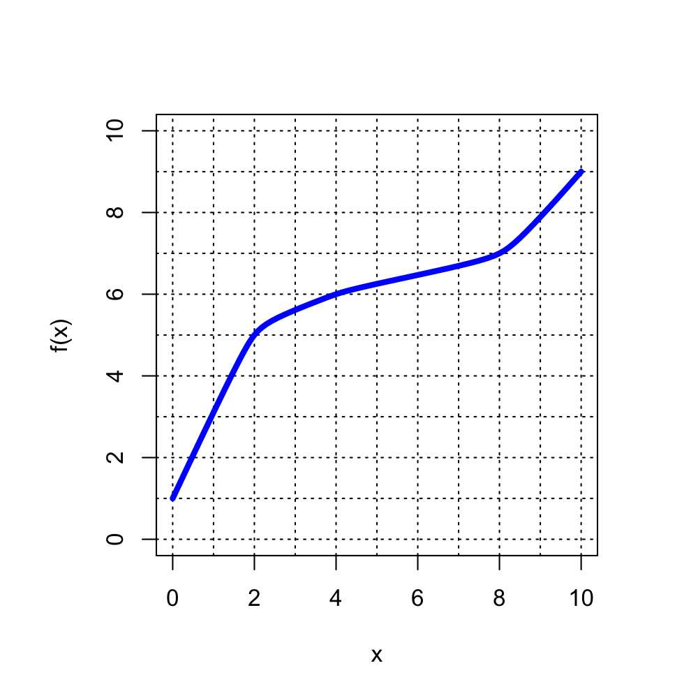

- If $f(x)=5$, then find $x$. In other words, evaluate $f^{-1}(5)$.

Look up [inverse functions](https://en.wikipedia.org/wiki/Inverse_function).

Find the correct point on the graph where $f(x)=5$.

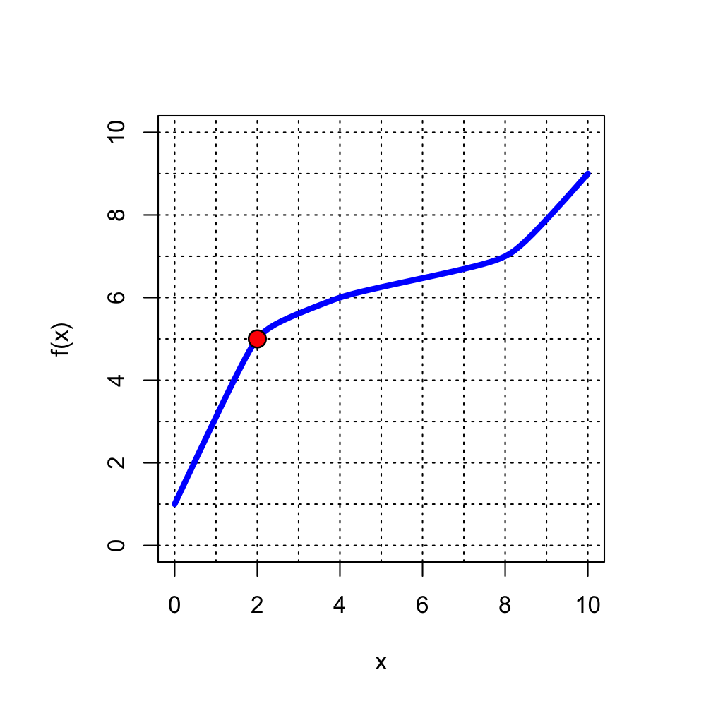

$$f(2)=5$$

Thus,

$$f^{-1}(5) ~=~ 2$$

A one-to-one function $f$ is graphed below.

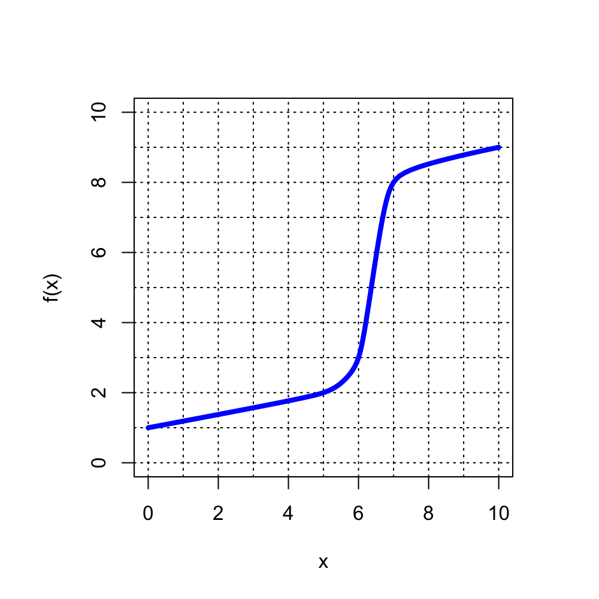

- If $f(x)=2$, then find $x$. In other words, evaluate $f^{-1}(2)$.

Look up [inverse functions](https://en.wikipedia.org/wiki/Inverse_function).

Find the correct point on the graph where $f(x)=2$.

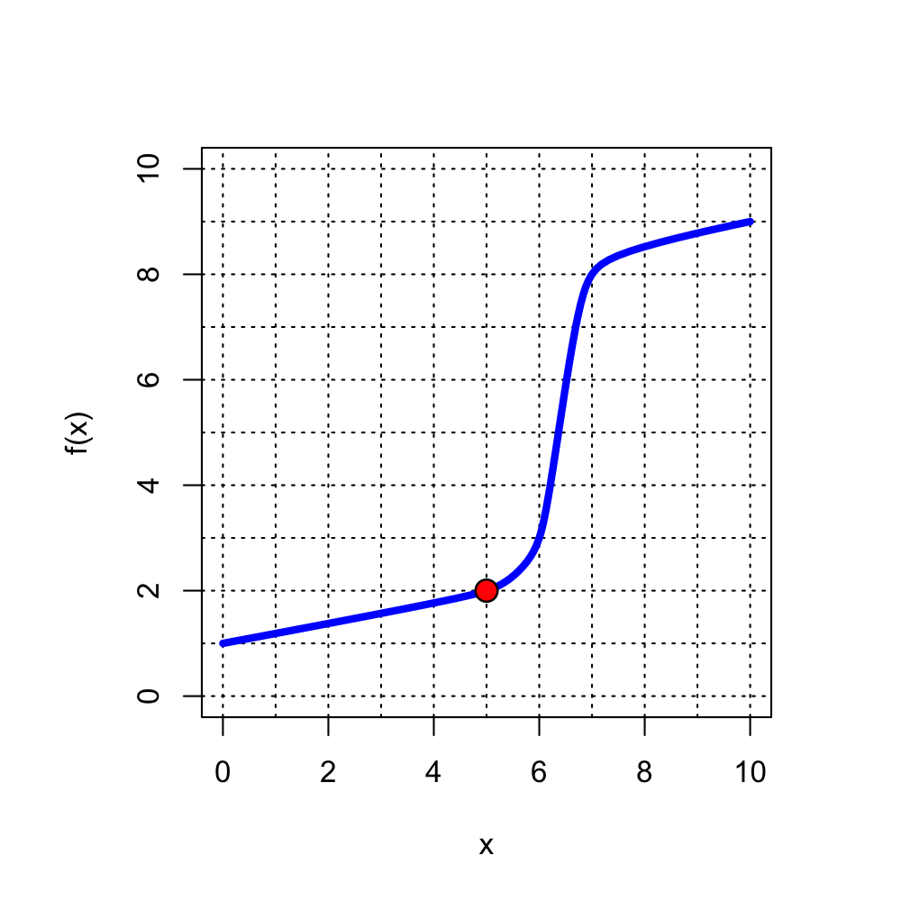

$$f(5)=2$$

Thus,

$$f^{-1}(2) ~=~ 5$$

A one-to-one function $f$ is graphed below.

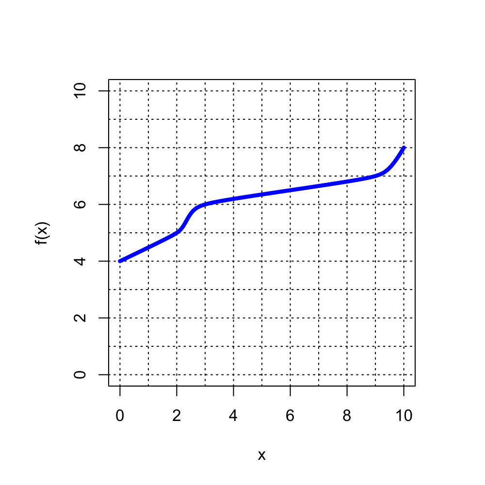

- If $f(x)=7$, then find $x$. In other words, evaluate $f^{-1}(7)$.

Look up [inverse functions](https://en.wikipedia.org/wiki/Inverse_function).

Find the correct point on the graph where $f(x)=7$.

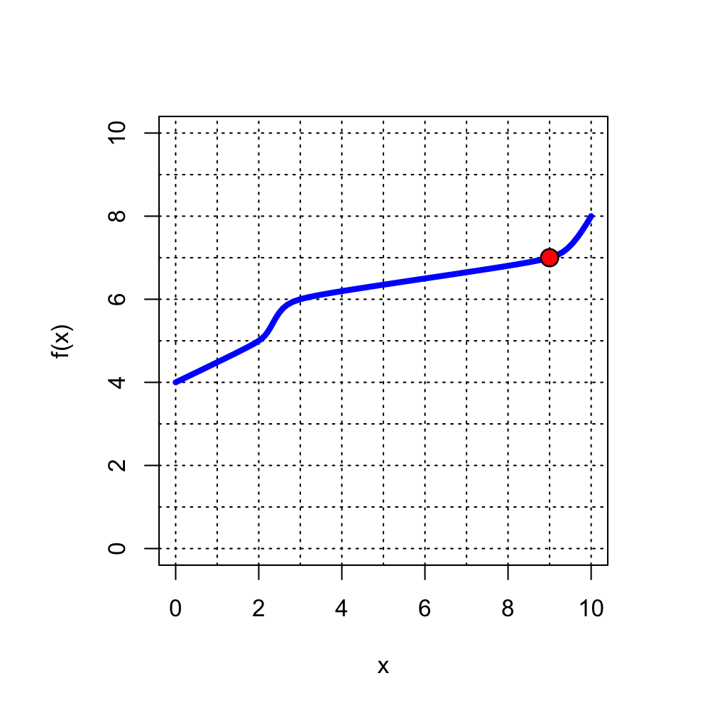

$$f(9)=7$$

Thus,

$$f^{-1}(7) ~=~ 9$$

A one-to-one function $f$ is graphed below.

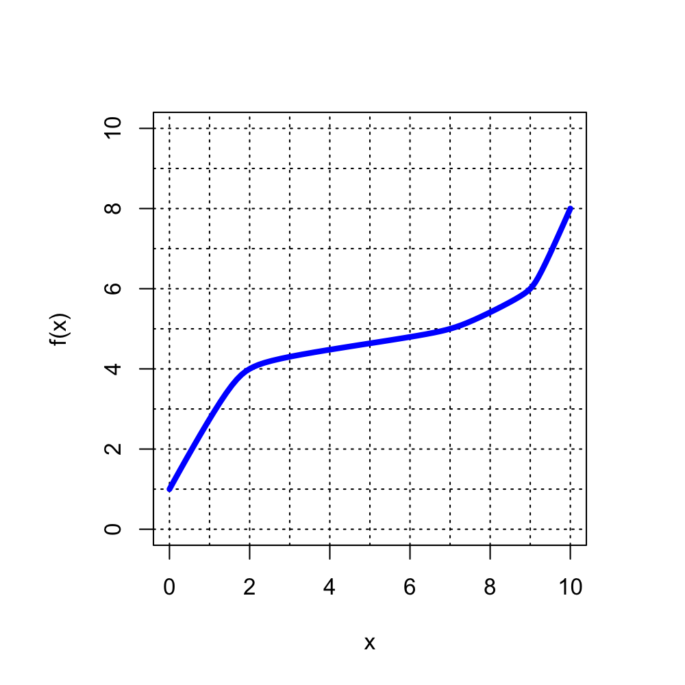

- If $f(x)=5$, then find $x$. In other words, evaluate $f^{-1}(5)$.

Look up [inverse functions](https://en.wikipedia.org/wiki/Inverse_function).

Find the correct point on the graph where $f(x)=5$.

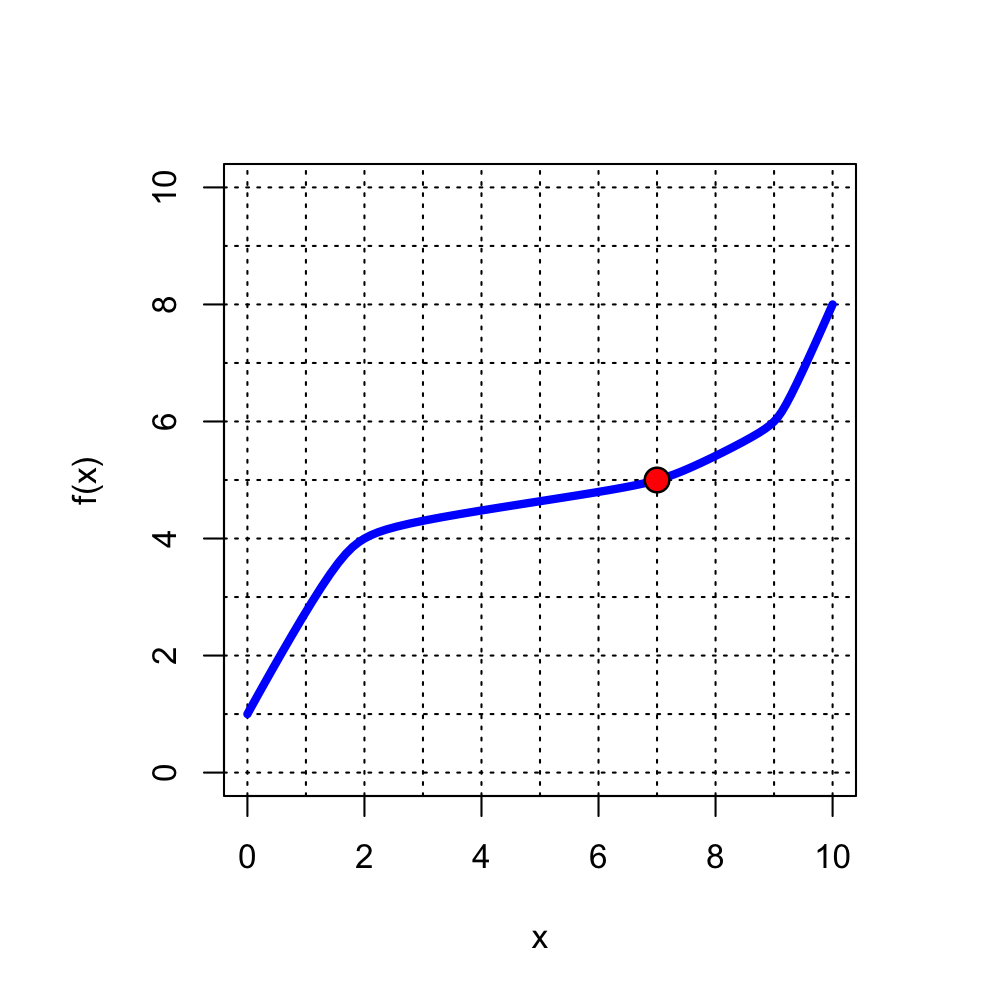

$$f(7)=5$$

Thus,

$$f^{-1}(5) ~=~ 7$$

A one-to-one function $f$ is graphed below.

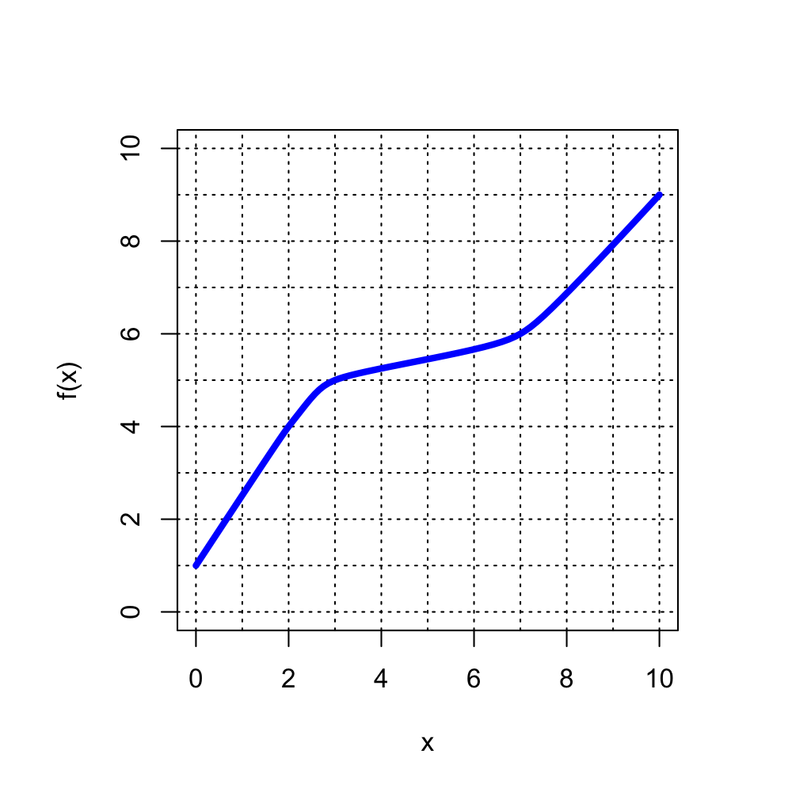

- If $f(x)=4$, then find $x$. In other words, evaluate $f^{-1}(4)$.

Look up [inverse functions](https://en.wikipedia.org/wiki/Inverse_function).

Find the correct point on the graph where $f(x)=4$.

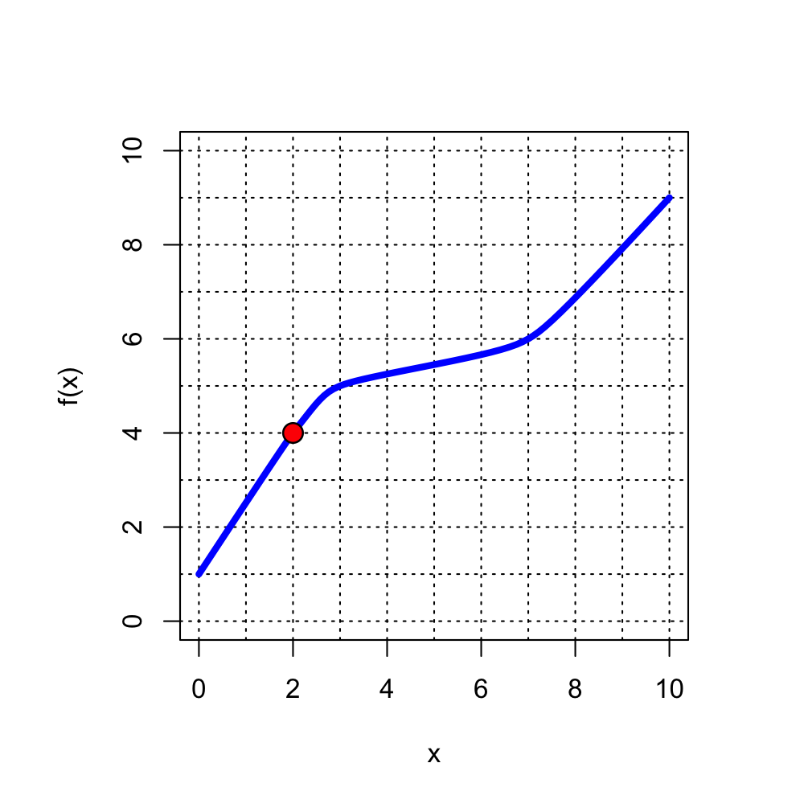

$$f(2)=4$$

Thus,

$$f^{-1}(4) ~=~ 2$$

A one-to-one function $f$ is graphed below.

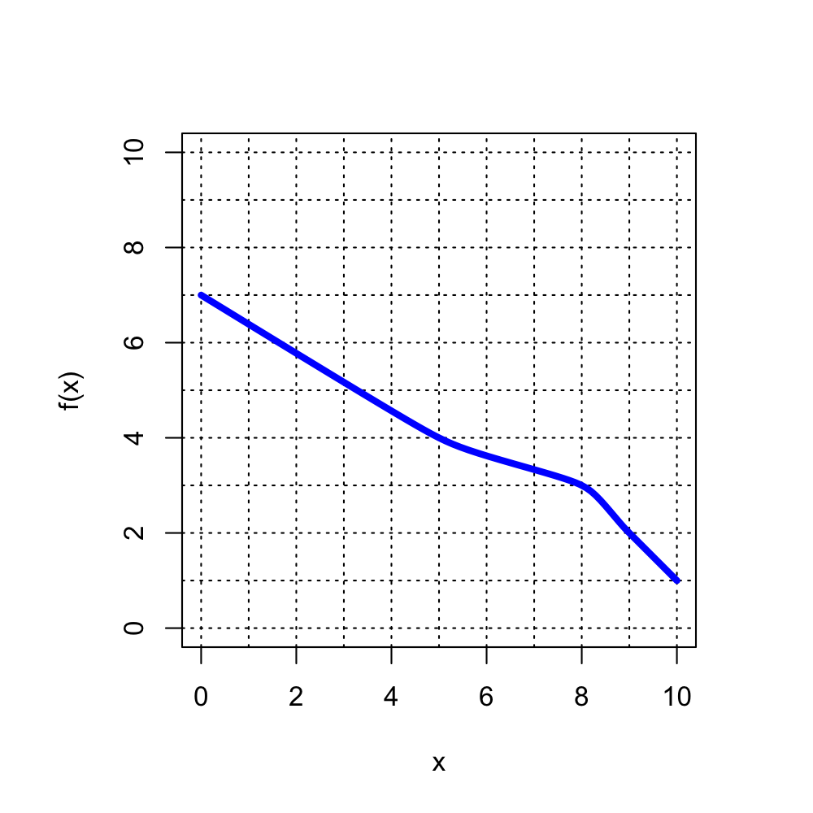

- If $f(x)=2$, then find $x$. In other words, evaluate $f^{-1}(2)$.

Look up [inverse functions](https://en.wikipedia.org/wiki/Inverse_function).

Find the correct point on the graph where $f(x)=2$.

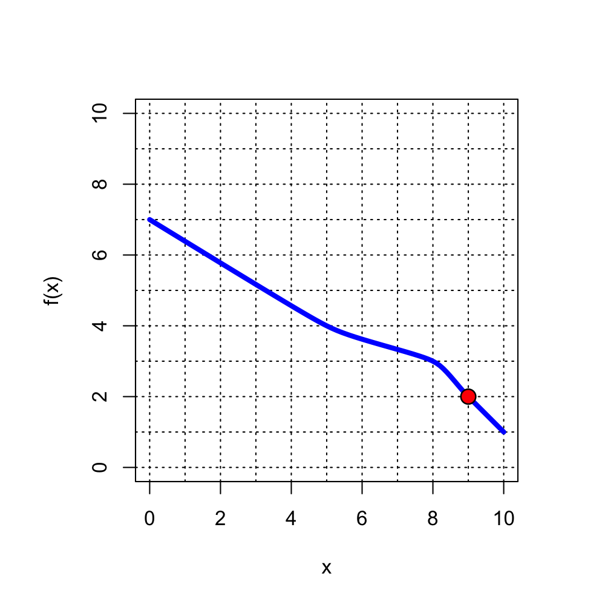

$$f(9)=2$$

Thus,

$$f^{-1}(2) ~=~ 9$$

A one-to-one function $f$ is graphed below.

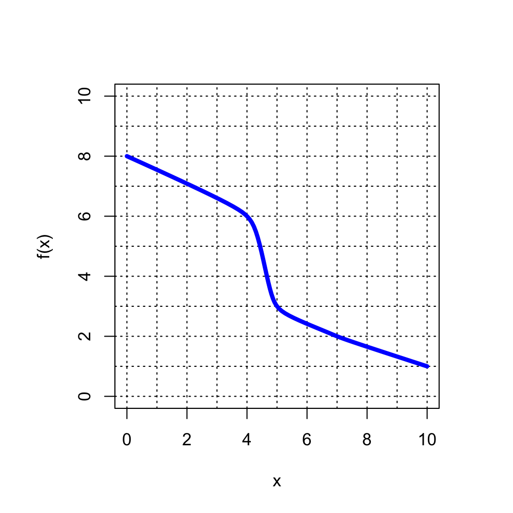

- If $f(x)=3$, then find $x$. In other words, evaluate $f^{-1}(3)$.

Look up [inverse functions](https://en.wikipedia.org/wiki/Inverse_function).

Find the correct point on the graph where $f(x)=3$.

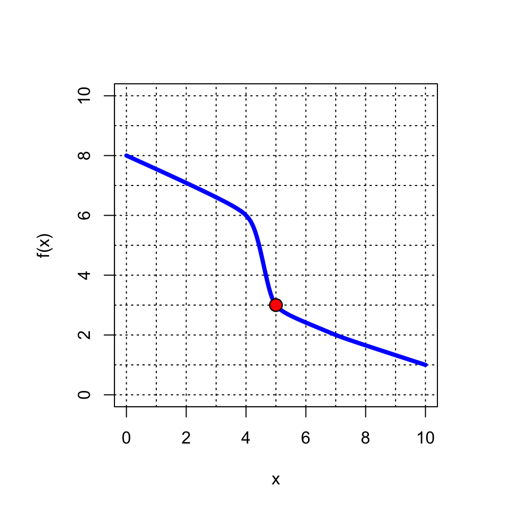

$$f(5)=3$$

Thus,

$$f^{-1}(3) ~=~ 5$$

A one-to-one function $f$ is graphed below.

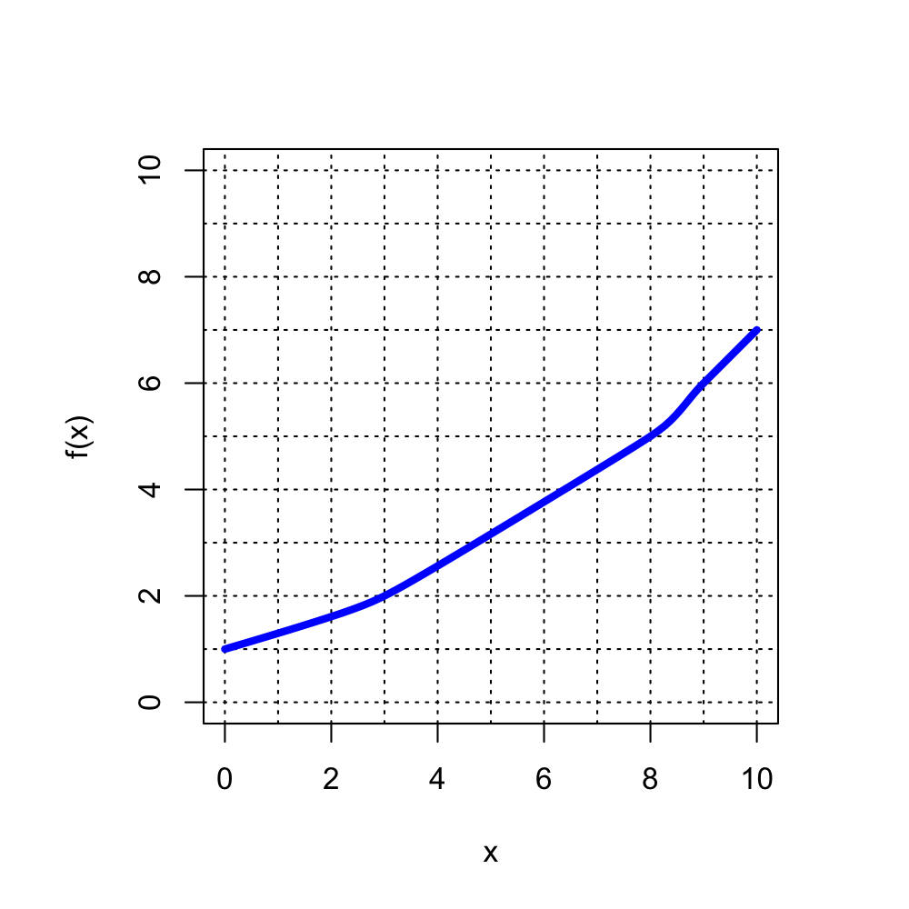

- If $f(x)=2$, then find $x$. In other words, evaluate $f^{-1}(2)$.

Look up [inverse functions](https://en.wikipedia.org/wiki/Inverse_function).

Find the correct point on the graph where $f(x)=2$.

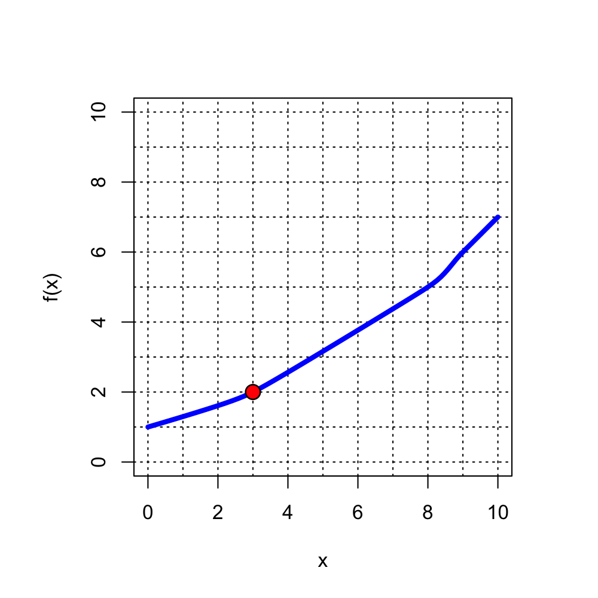

$$f(3)=2$$

Thus,

$$f^{-1}(2) ~=~ 3$$

A one-to-one function $f$ is graphed below.

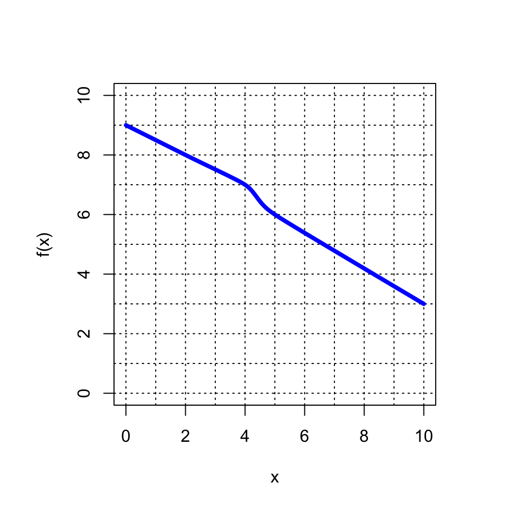

- If $f(x)=8$, then find $x$. In other words, evaluate $f^{-1}(8)$.

Look up [inverse functions](https://en.wikipedia.org/wiki/Inverse_function).

Find the correct point on the graph where $f(x)=8$.

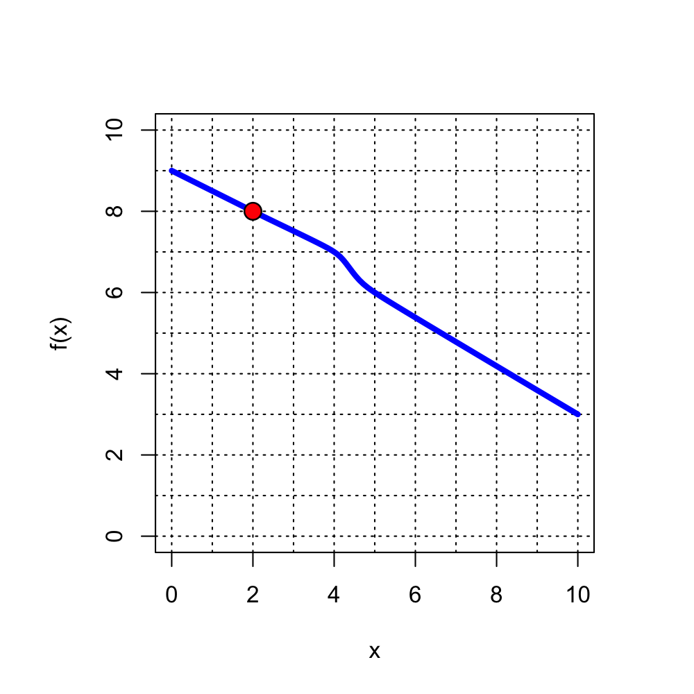

$$f(2)=8$$

Thus,

$$f^{-1}(8) ~=~ 2$$

A one-to-one function $f$ is graphed below.

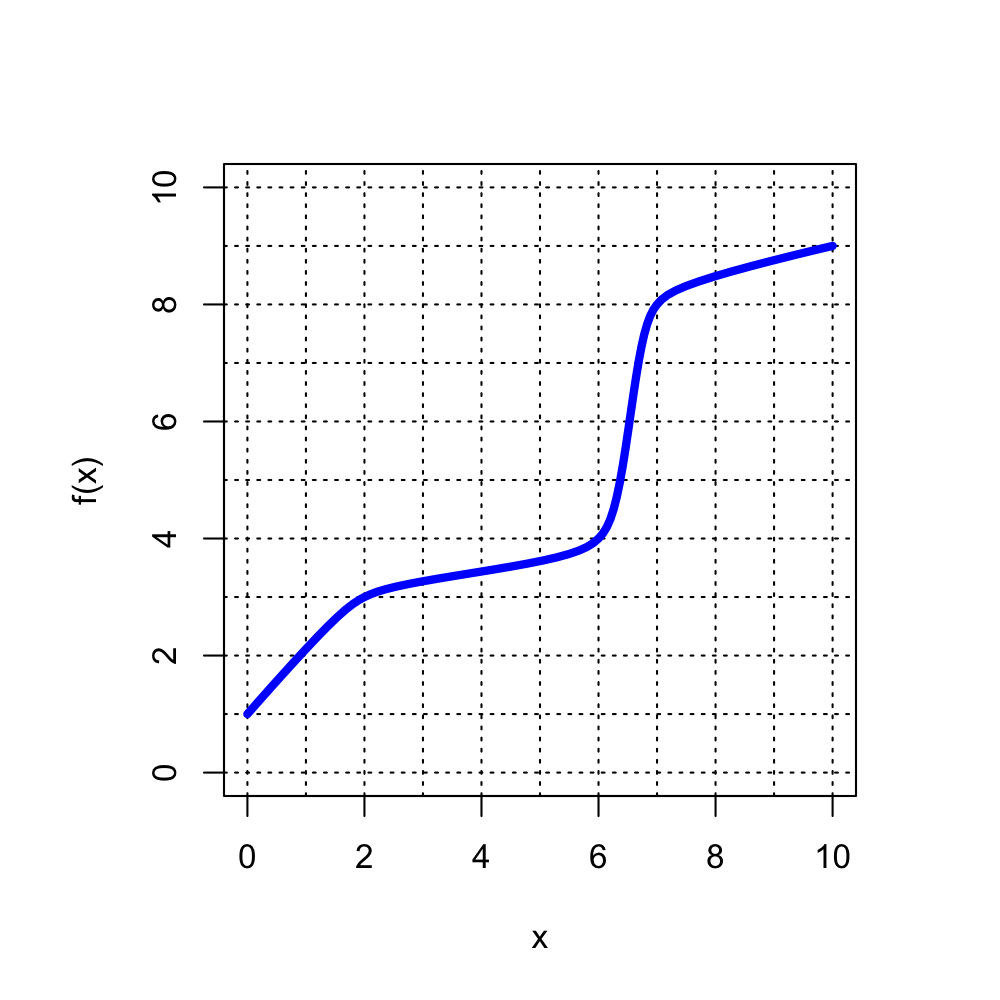

- If $f(x)=4$, then find $x$. In other words, evaluate $f^{-1}(4)$.

Look up [inverse functions](https://en.wikipedia.org/wiki/Inverse_function).

Find the correct point on the graph where $f(x)=4$.

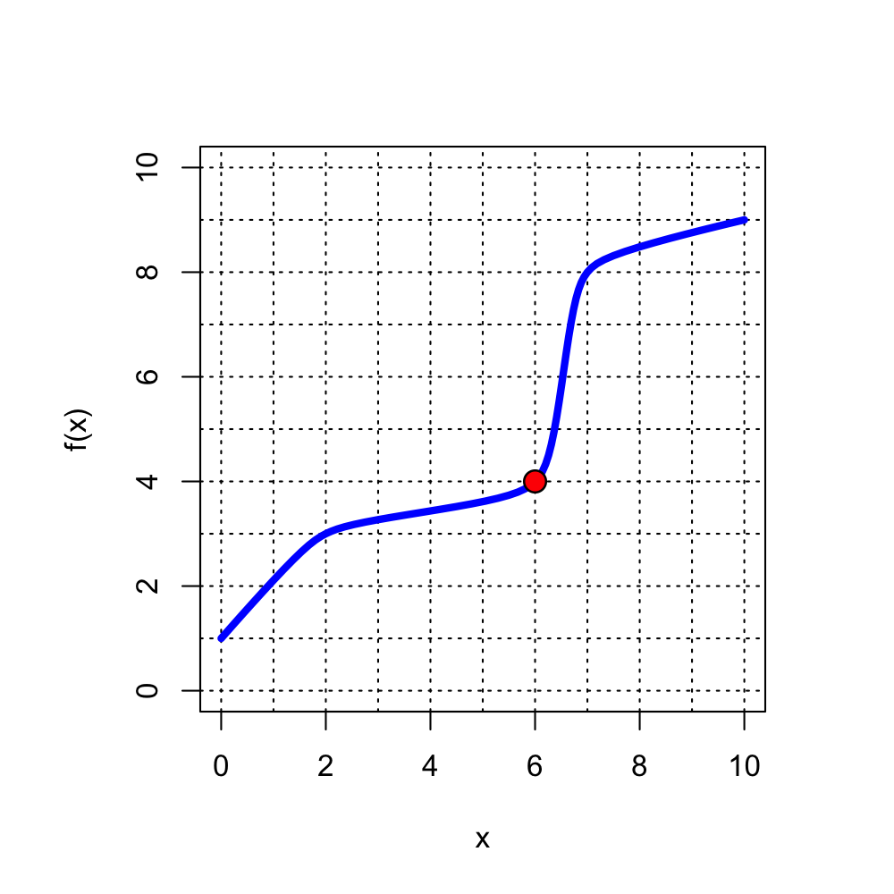

$$f(6)=4$$

Thus,

$$f^{-1}(4) ~=~ 6$$

Let a [one-to-one function](https://en.wikipedia.org/wiki/Injective_function), $f$, be defined by the table below.

| $x$ | $f(x)$ |
| --- | --- |
| 1 | 2 |
| 2 | 6 |
| 3 | 1 |
| 4 | 5 |
| 5 | 7 |
| 6 | 4 |
| 7 | 3 |

Create the [inverse function's](https://en.wikipedia.org/wiki/Inverse_function) table.

| $x$ | $f^{-1}(x)$ |
| --- | --- |
| 1 |  |
| 2 |  |
| 3 |  |
| 4 |  |
| 5 |  |
| 6 |  |
| 7 |  |

The inverse function $f^{-1}$ is defined by the table below.

| $x$ | $f^{-1}(x)$ |
| --- | --- |
| 1 | 3 |
| 2 | 1 |
| 3 | 7 |
| 4 | 6 |
| 5 | 4 |
| 6 | 2 |
| 7 | 5 |

Notice, you just switch the columns of the given $f$ table and then sort by the first column.

Let a [one-to-one function](https://en.wikipedia.org/wiki/Injective_function), $f$, be defined by the table below.

| $x$ | $f(x)$ |
| --- | --- |
| 1 | 2 |
| 2 | 4 |
| 3 | 7 |
| 4 | 6 |
| 5 | 3 |
| 6 | 1 |
| 7 | 5 |

Create the [inverse function's](https://en.wikipedia.org/wiki/Inverse_function) table.

| $x$ | $f^{-1}(x)$ |
| --- | --- |
| 1 |  |
| 2 |  |
| 3 |  |
| 4 |  |
| 5 |  |
| 6 |  |
| 7 |  |

The inverse function $f^{-1}$ is defined by the table below.

| $x$ | $f^{-1}(x)$ |
| --- | --- |
| 1 | 6 |
| 2 | 1 |
| 3 | 5 |
| 4 | 2 |
| 5 | 7 |
| 6 | 4 |
| 7 | 3 |

Notice, you just switch the columns of the given $f$ table and then sort by the first column.

Let a [one-to-one function](https://en.wikipedia.org/wiki/Injective_function), $f$, be defined by the table below.

| $x$ | $f(x)$ |
| --- | --- |
| 1 | 7 |
| 2 | 5 |
| 3 | 4 |
| 4 | 1 |
| 5 | 6 |
| 6 | 2 |
| 7 | 3 |

Create the [inverse function's](https://en.wikipedia.org/wiki/Inverse_function) table.

| $x$ | $f^{-1}(x)$ |
| --- | --- |
| 1 |  |
| 2 |  |
| 3 |  |
| 4 |  |
| 5 |  |
| 6 |  |
| 7 |  |

The inverse function $f^{-1}$ is defined by the table below.

| $x$ | $f^{-1}(x)$ |
| --- | --- |
| 1 | 4 |
| 2 | 6 |
| 3 | 7 |
| 4 | 3 |
| 5 | 2 |
| 6 | 5 |
| 7 | 1 |

Notice, you just switch the columns of the given $f$ table and then sort by the first column.

Let a [one-to-one function](https://en.wikipedia.org/wiki/Injective_function), $f$, be defined by the table below.

| $x$ | $f(x)$ |
| --- | --- |
| 1 | 7 |
| 2 | 6 |
| 3 | 2 |
| 4 | 3 |
| 5 | 1 |
| 6 | 4 |
| 7 | 5 |

Create the [inverse function's](https://en.wikipedia.org/wiki/Inverse_function) table.

| $x$ | $f^{-1}(x)$ |
| --- | --- |
| 1 |  |
| 2 |  |
| 3 |  |
| 4 |  |
| 5 |  |
| 6 |  |
| 7 |  |

The inverse function $f^{-1}$ is defined by the table below.

| $x$ | $f^{-1}(x)$ |
| --- | --- |
| 1 | 5 |
| 2 | 3 |
| 3 | 4 |
| 4 | 6 |
| 5 | 7 |
| 6 | 2 |
| 7 | 1 |

Notice, you just switch the columns of the given $f$ table and then sort by the first column.

Let a [one-to-one function](https://en.wikipedia.org/wiki/Injective_function), $f$, be defined by the table below.

| $x$ | $f(x)$ |
| --- | --- |
| 1 | 3 |
| 2 | 5 |
| 3 | 4 |
| 4 | 6 |
| 5 | 7 |
| 6 | 1 |
| 7 | 2 |

Create the [inverse function's](https://en.wikipedia.org/wiki/Inverse_function) table.

| $x$ | $f^{-1}(x)$ |
| --- | --- |
| 1 |  |
| 2 |  |
| 3 |  |
| 4 |  |
| 5 |  |
| 6 |  |
| 7 |  |

The inverse function $f^{-1}$ is defined by the table below.

| $x$ | $f^{-1}(x)$ |
| --- | --- |
| 1 | 6 |
| 2 | 7 |
| 3 | 1 |
| 4 | 3 |
| 5 | 2 |
| 6 | 4 |
| 7 | 5 |

Notice, you just switch the columns of the given $f$ table and then sort by the first column.

Let a [one-to-one function](https://en.wikipedia.org/wiki/Injective_function), $f$, be defined by the table below.

| $x$ | $f(x)$ |
| --- | --- |
| 1 | 2 |
| 2 | 5 |
| 3 | 7 |
| 4 | 6 |
| 5 | 4 |
| 6 | 3 |
| 7 | 1 |

Create the [inverse function's](https://en.wikipedia.org/wiki/Inverse_function) table.

| $x$ | $f^{-1}(x)$ |
| --- | --- |
| 1 |  |
| 2 |  |
| 3 |  |
| 4 |  |
| 5 |  |
| 6 |  |
| 7 |  |

The inverse function $f^{-1}$ is defined by the table below.

| $x$ | $f^{-1}(x)$ |
| --- | --- |
| 1 | 7 |
| 2 | 1 |
| 3 | 6 |
| 4 | 5 |
| 5 | 2 |
| 6 | 4 |
| 7 | 3 |

Notice, you just switch the columns of the given $f$ table and then sort by the first column.

Let a [one-to-one function](https://en.wikipedia.org/wiki/Injective_function), $f$, be defined by the table below.

| $x$ | $f(x)$ |
| --- | --- |
| 1 | 3 |
| 2 | 7 |
| 3 | 4 |
| 4 | 6 |
| 5 | 2 |
| 6 | 5 |
| 7 | 1 |

Create the [inverse function's](https://en.wikipedia.org/wiki/Inverse_function) table.

| $x$ | $f^{-1}(x)$ |
| --- | --- |
| 1 |  |
| 2 |  |
| 3 |  |
| 4 |  |
| 5 |  |
| 6 |  |
| 7 |  |

The inverse function $f^{-1}$ is defined by the table below.

| $x$ | $f^{-1}(x)$ |
| --- | --- |
| 1 | 7 |
| 2 | 5 |
| 3 | 1 |
| 4 | 3 |
| 5 | 6 |
| 6 | 4 |
| 7 | 2 |

Notice, you just switch the columns of the given $f$ table and then sort by the first column.

Let a [one-to-one function](https://en.wikipedia.org/wiki/Injective_function), $f$, be defined by the table below.

| $x$ | $f(x)$ |
| --- | --- |
| 1 | 6 |
| 2 | 1 |
| 3 | 7 |
| 4 | 3 |
| 5 | 2 |
| 6 | 4 |
| 7 | 5 |

Create the [inverse function's](https://en.wikipedia.org/wiki/Inverse_function) table.

| $x$ | $f^{-1}(x)$ |
| --- | --- |
| 1 |  |
| 2 |  |
| 3 |  |
| 4 |  |
| 5 |  |
| 6 |  |
| 7 |  |

The inverse function $f^{-1}$ is defined by the table below.

| $x$ | $f^{-1}(x)$ |
| --- | --- |
| 1 | 2 |
| 2 | 5 |
| 3 | 4 |
| 4 | 6 |
| 5 | 7 |
| 6 | 1 |
| 7 | 3 |

Notice, you just switch the columns of the given $f$ table and then sort by the first column.

Let a [one-to-one function](https://en.wikipedia.org/wiki/Injective_function), $f$, be defined by the table below.

| $x$ | $f(x)$ |
| --- | --- |
| 1 | 6 |
| 2 | 3 |
| 3 | 1 |
| 4 | 5 |
| 5 | 7 |
| 6 | 2 |
| 7 | 4 |

Create the [inverse function's](https://en.wikipedia.org/wiki/Inverse_function) table.

| $x$ | $f^{-1}(x)$ |
| --- | --- |
| 1 |  |
| 2 |  |
| 3 |  |
| 4 |  |
| 5 |  |
| 6 |  |
| 7 |  |

The inverse function $f^{-1}$ is defined by the table below.

| $x$ | $f^{-1}(x)$ |
| --- | --- |
| 1 | 3 |
| 2 | 6 |
| 3 | 2 |
| 4 | 7 |
| 5 | 4 |
| 6 | 1 |
| 7 | 5 |

Notice, you just switch the columns of the given $f$ table and then sort by the first column.

Let a [one-to-one function](https://en.wikipedia.org/wiki/Injective_function), $f$, be defined by the table below.

| $x$ | $f(x)$ |
| --- | --- |
| 1 | 6 |
| 2 | 3 |
| 3 | 1 |
| 4 | 5 |
| 5 | 2 |
| 6 | 7 |
| 7 | 4 |

Create the [inverse function's](https://en.wikipedia.org/wiki/Inverse_function) table.

| $x$ | $f^{-1}(x)$ |
| --- | --- |
| 1 |  |
| 2 |  |
| 3 |  |
| 4 |  |
| 5 |  |
| 6 |  |
| 7 |  |

The inverse function $f^{-1}$ is defined by the table below.

| $x$ | $f^{-1}(x)$ |
| --- | --- |
| 1 | 3 |
| 2 | 5 |
| 3 | 2 |
| 4 | 7 |
| 5 | 4 |
| 6 | 1 |
| 7 | 6 |

Notice, you just switch the columns of the given $f$ table and then sort by the first column.

The [one-to-one](https://en.wikipedia.org/wiki/Injective_function) function $f$ is plotted below:

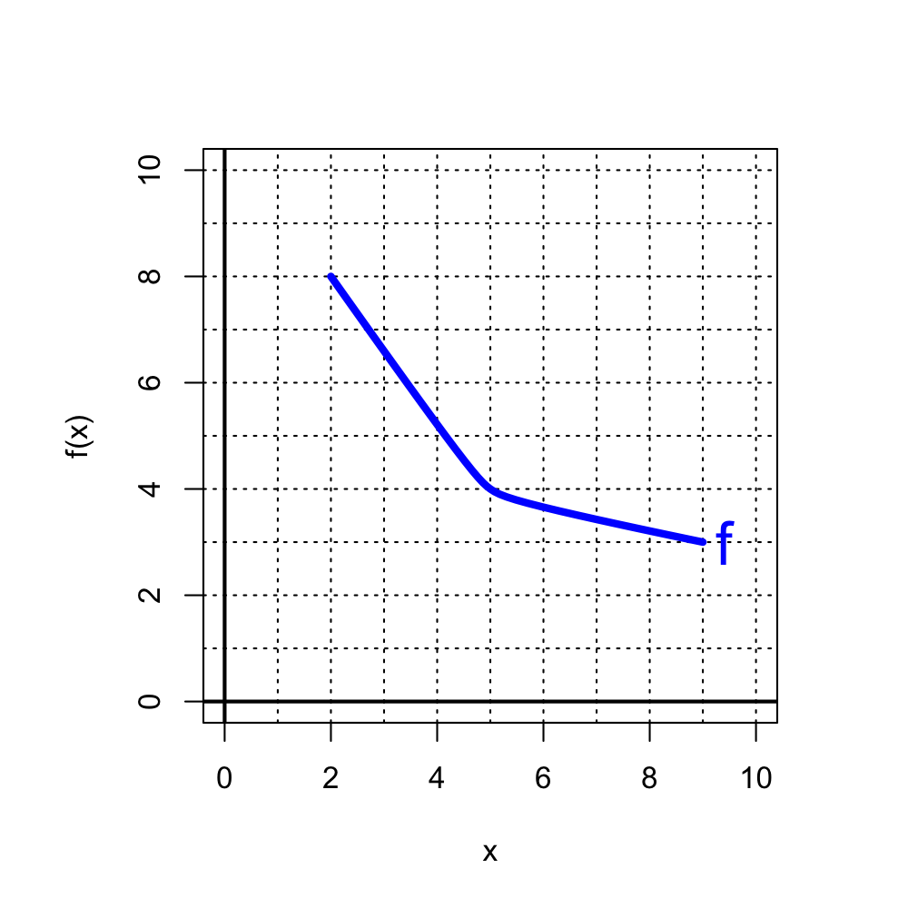

Which of the following red curves is a graph of the inverse function, $f^{-1}$?

- A

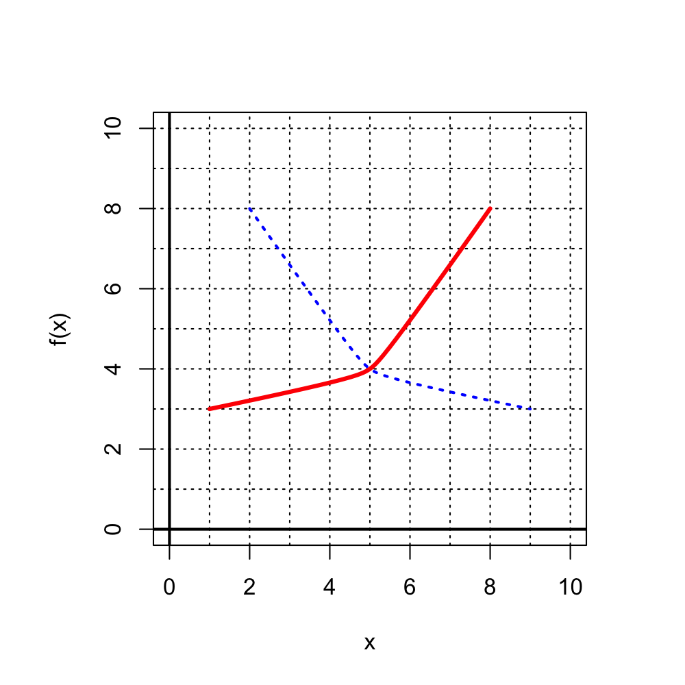

- B

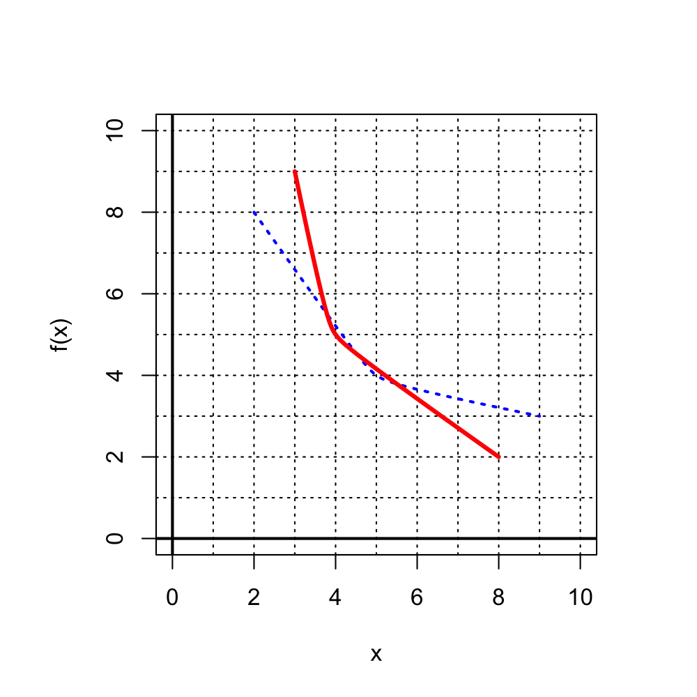

- C

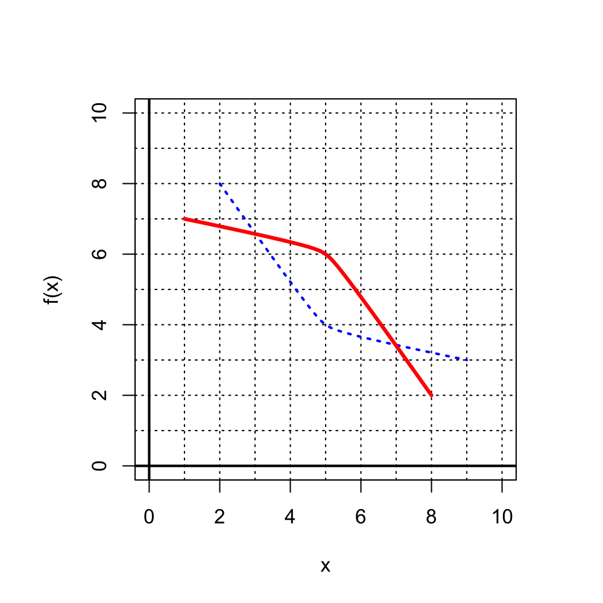

- D

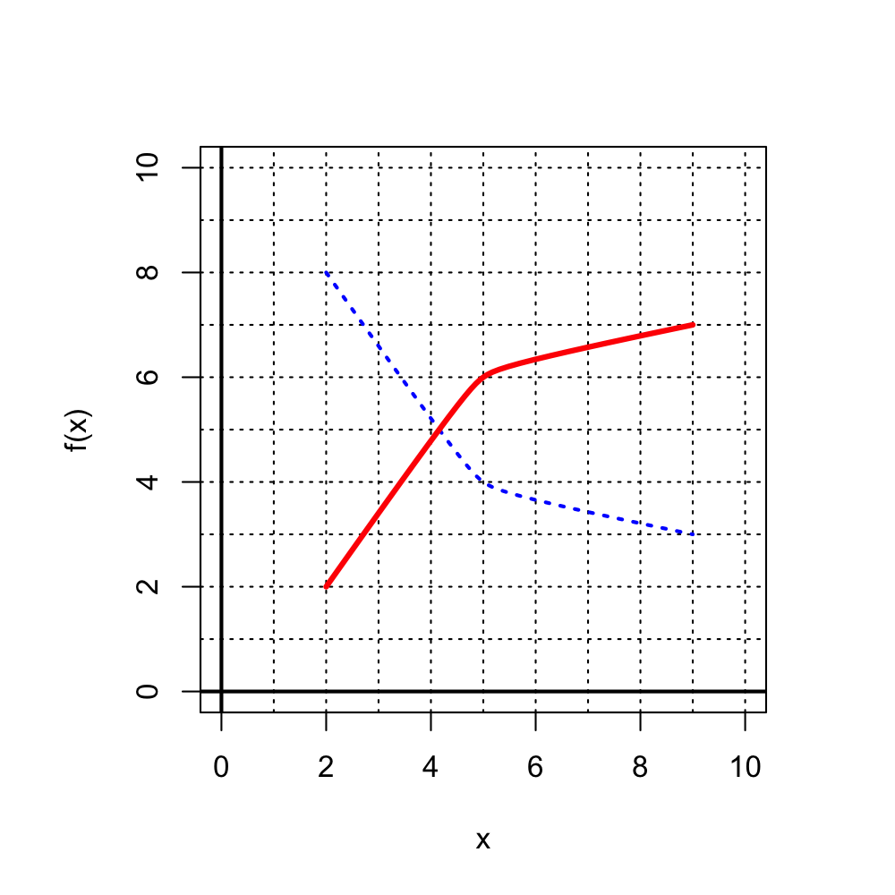

ABCD

The correct answer should have reflective symmetry across the $y=x$ line, also known as the 45$^\circ$ line.

So, the correct answer is B:

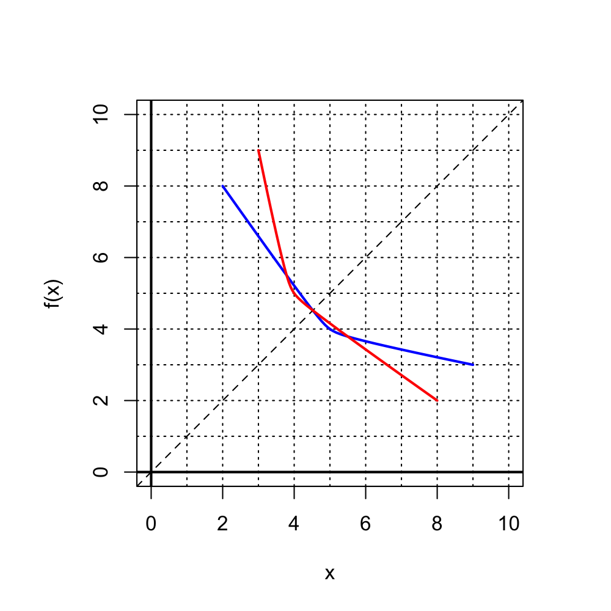

The [one-to-one](https://en.wikipedia.org/wiki/Injective_function) function $f$ is plotted below:

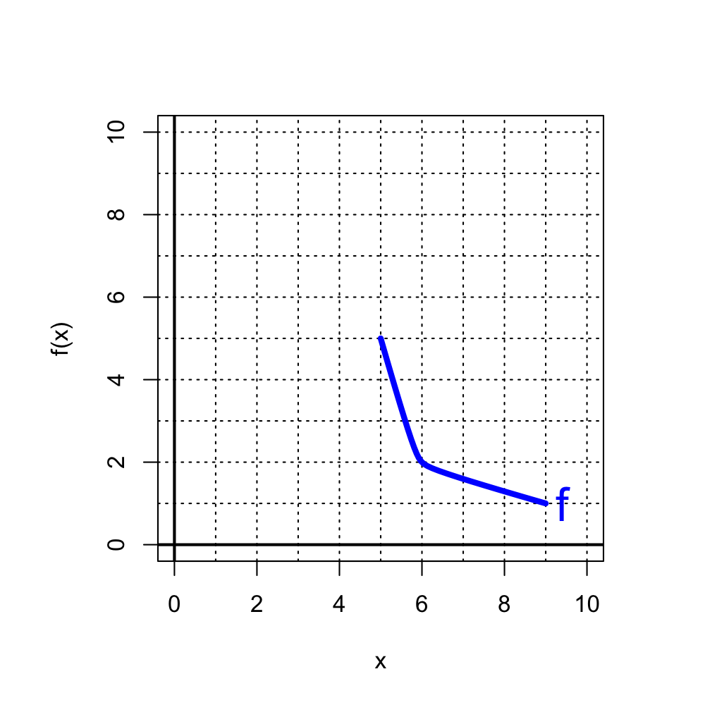

Which of the following red curves is a graph of the inverse function, $f^{-1}$?

- A

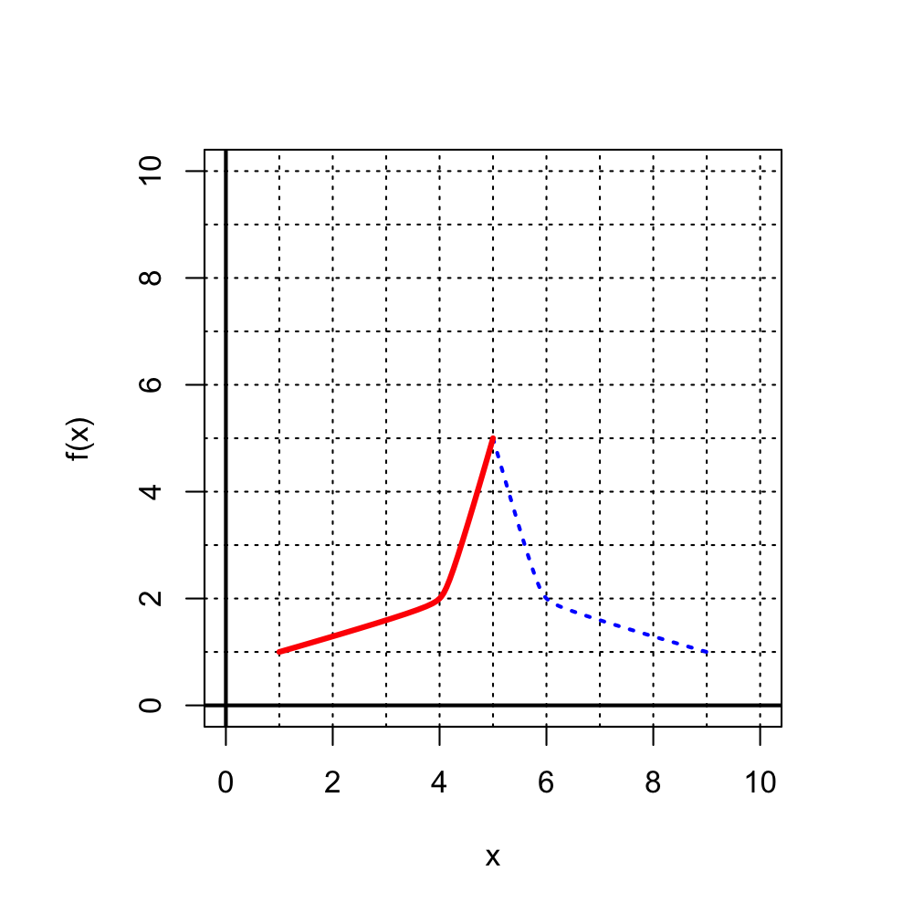

- B

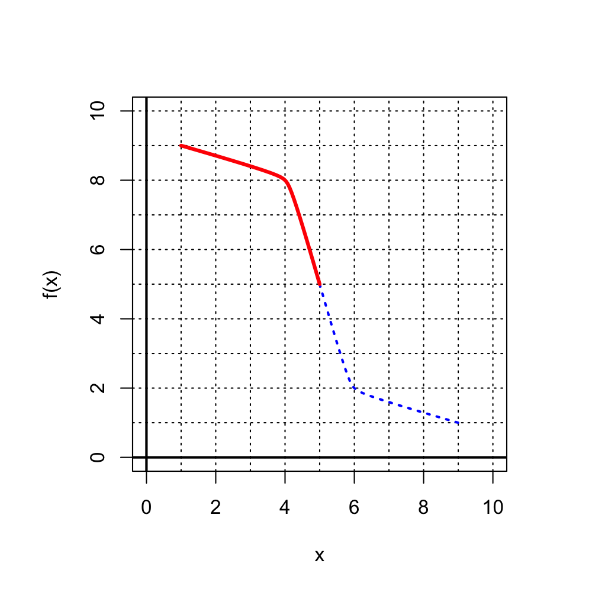

- C

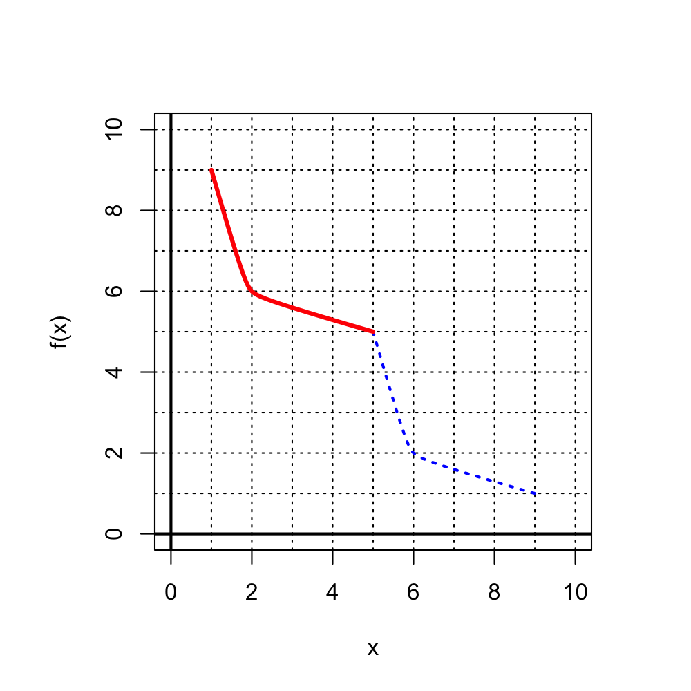

- D

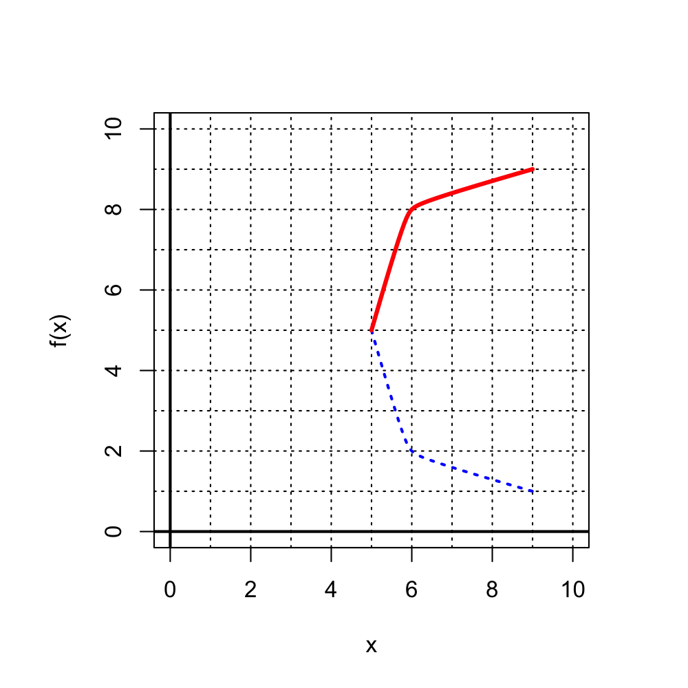

ABCD